# IE 582 - Homework - 5

Elif Erdinç

January 7, 2019

## 1. Introduction

Multiple Instance Learning (MIL) is learning framework which deals with uncertainty of instance labels. In this setting training data is available only as pairs of bags of instances with labels for the bags. Instance labels remain unknown and might be inferred during learning. A positive bag label indicates that at least one instance of that bag can be assigned a positive label. This instance can therefore be thought of as a witness for the label. Instance in negative labelled bags are altogether of the negative class, so there is no uncertainty about their label.

In this homework, MIL is practiced based on a Musk dataset available in the link: https://archive.ics.uci.edu/ml/datasets/Musk+(Version+1). This dataset contains a set of 92 molecules of which 47 are judged by human experts to be musks and the remaining 45 molecules are judged to be non-musks. This is a classification problem with 0 indication of non-musk and 1 for musk class. Molecules are defined with 166 features. Regarding the fact that a single molecule can be in different shapes, different conformations of molecule are gathered in single bags. In this data set 476 conformations are grouped in 92 bags.

The aim of this homework is to identify a class of smell (musk or non-musk) for each bag (different conformations of a molecule) using MIL.

## 2. Algorithm

Below listed steps are followed to reduce the conformation level information to bag level:

**1.** 476 conformations are clustered using kmeans and hierarchical clustering methods. In this clustering approaches both Euclidean and Manhattan distances are taken as basis. For kmeans calculations, k-medoids aprroach is adopted and pam function of cluster package is used. Different levels of k values (3, 5, 7, 10, 12, 15, 17, 20, 22, 25, 30, 40) are tested. For hierarchical clustering calculations, hclust function of stats package is used and above listed k values are tried as tree cut levels.

**2.** Centroids for each above mentioned trial are found. For pam function it is already integrated and can be called via $medoids. However, for hclust function, centroids of each cluster is found using a custom-made function. Distances of each instance to its cluster centroid are calculated for both Manhattan and Euclidean distances.

**3.** By taking the averages of the instances bag-wise, conformation base (476 instances) are converted to bag base (92 instances).

**6.** In the for loop, models are run and accuracies are calculated for each model.

**7.** Deciding on the optimal model (kmeans vs hierarchical, Euclidean vs Manhattan, which k value), performance of the model is summarized through the ROC curve.

## 3. Results and Discussions

As mentioned above, for 2 methods (kmeans & hierarchical clustering), 2 distance calculations (Euclidean & Manhattan) and 12 different (3, 5, 7, 10, 12, 15, 17, 20, 22, 25, 30, 40) k value or tree cut levels models were constructed and accuracies on the train data are calculated. **Figure 1** summarizes the change in the accuracies for all models. As expected, in general increasing the k value or tree cut level increased the accuracy. However, after a certain point increasing these values will cause an overfitting issue.

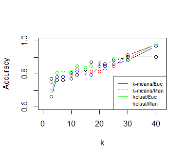

**Figure 1** - Comparison of accuracies for k-means and hierarchical clustering using both Euclidean and Manhattan distances.

It is hard to conclude that any one of these 4 model structures is better than the others.

As known in the literature, using the k value of square root of the half of the number of instances is quite optimal for the model. When it is calculated for dataset of 476 instances, 15.4 is found. In **Figure 1**, when the close neighborhood of k = 15 is investigated, it is observed that the model in which k-means method with k equals to 17 applied using Manhattan distances shows higher accuracy among others. Therefore, ROC curve is plotted based on this model. ROCR package is used to plot ROC curve and can be seen in **Figure 2**. The area under the curve shows the accuracy of the model.

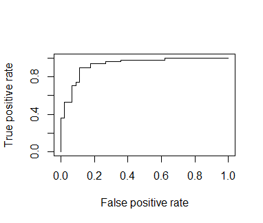

**Figure 2** - ROC curve for the final model based on k-means (k=17) using Manhattan distance.

## 4. Appendix: Code

```r
#include=TRUE writes the code on document
#eval=FALSE doesn't run the code during knitting
require(stats)
require(TSdist)
require(cluster)

set.seed(123)

data=read.csv(file="C:/Users/09172/Desktop/PhD Dersler/2018-2/IE 582/HW files/HW5/Musk1.csv", header = FALSE, sep = ",")
#data= as.data.frame(data)

# bag=data[,2]
# bagID=unique(bag)

d=c(3,5,7,10,12,15,17,20,22,25,30,40)
acc_E=array()
acc_M=array()
acc_E_h=array()
acc_M_h=array()

#########################
# function to find medoid in cluster i
clust.centroid = function(z, dat, clusters) {
  ind = (clusters == z)
  colMeans(dat[ind,])
}
##########################

for (i in 1:length(d)) {

k=d[i]
distE=data.frame()
distM=data.frame()
distE_h=data.frame()
distM_h=data.frame()

n=nrow(data)

# Euclidean  - kmeans

cluster_E=pam(data[,3:length(data)],k,metric = "euclidean")
center_E=cluster_E$medoids
#clusters=cluster$cluster

# Manhattan - kmeans

cluster_M=pam(data[,3:length(data)],k,metric = "manhattan")
center_M=cluster_M$medoids

# Euclidean  - hierarchical
h_cluster_E = hclust(dist(data[,3:length(data)], method = "euclidean"), method = "average")
clust_E <- cutree(h_cluster_E, k = k)
# table(clust_E,class_E)
# h_center_E=clust.centroid(k,data[,3:length(data)], clust_E)

h_center_E=NULL

for (s in 1:k) {
  h_center_E <- rbind(h_center_E, colMeans(data[,3:length(data)][clust_E == s, , drop = FALSE]))
}

# Manhattan  - hierarchical
h_cluster_M = hclust(dist(data[,3:length(data)], method = "manhattan"), method = "average")
clust_M <- cutree(h_cluster_M, k = k)

h_center_M=NULL

for (s in 1:k) {
  h_center_M <- rbind(h_center_M, colMeans(data[,3:length(data)][clust_M == s, , drop = FALSE]))
}


for (j in 1:n) {
    for (p in 1:k){
        distE[j,p]=EuclideanDistance(as.double(data[j,3:length(data)]), as.vector(center_E[p,]))
        distM[j,p]=ManhattanDistance(as.double(data[j,3:length(data)]), as.vector(center_M[p,]))
        distE_h[j,p]=EuclideanDistance(as.double(data[j,3:length(data)]), as.vector(h_center_E[p,]))
        distM_h[j,p]=ManhattanDistance(as.double(data[j,3:length(data)]), as.vector(h_center_M[p,]))
         # distE=dist(as.double(data[1,3:length(data)]), as.vector(center[[1]][1,]))
  }}


dat_E = cbind(data[,1:2], distE)
dat_M = cbind(data[,1:2], distM)
dat_E_h = cbind(data[,1:2], distE_h)
dat_M_h = cbind(data[,1:2], distM_h)

# colnames(dat_E) = c("v1","v2","v3","v4","v5")
# colnames(dat_M) = c("v1","v2","v3","v4","v5")
# dat_E_2 = aggregate(.~v2, data=dat_E, mean)
# dat_M_2 = aggregate(.~v2, data=dat_M, mean)

dat_E_2= aggregate(dat_E, by=list(dat_E[,2]), mean)
dat_M_2= aggregate(dat_M, by=list(dat_M[,2]), mean)
dat_E_2_h= aggregate(dat_E_h, by=list(dat_E_h[,2]), mean)
dat_M_2_h= aggregate(dat_M_h, by=list(dat_M_h[,2]), mean)

# LASSO
library(caret)
dat_E_2[,c(1,3)]=NULL
dat_M_2[,c(1,3)]=NULL
dat_E_2_h[,c(1,3)]=NULL
dat_M_2_h[,c(1,3)]=NULL
#
class_E=as.factor(dat_E_2[,1])
class_M=as.factor(dat_M_2[,1])
class_E_h=as.factor(dat_E_2_h[,1])
class_M_h=as.factor(dat_M_2_h[,1])
# dat_E_2=as.data.frame(dat_E_2)
m=k+1
colnames(dat_E_2) <- c(paste0("v", 1:m))
colnames(dat_M_2) <- c(paste0("v", 1:m))
colnames(dat_E_2_h) <- c(paste0("v", 1:m))
colnames(dat_M_2_h) <- c(paste0("v", 1:m))

# Euclidean  - kmeans - accuracy
model_E = train(as.factor(v1)~.,data=dat_E_2, method="pda", metric="Accuracy", maximize = TRUE,
             trControl=trainControl("cv",number=10))

predicted_E = predict(model_E, dat_E_2)
tbl_E=table(predicted_E, class_E)
acc_E[i]=sum(diag(tbl_E))/length(class_E)

# Manhattan - kmeans - accuracy
model_M = train(as.factor(v1)~.,data=dat_M_2, method="pda", metric="Accuracy", maximize = TRUE,
                trControl=trainControl("cv",number=10))

predicted_M = predict(model_M, dat_M_2)
tbl_M=table(predicted_M, class_M)
acc_M[i]=sum(diag(tbl_M))/length(class_M)

# Euclidean  - hierarchical - accuracy
model_E_h = train(as.factor(v1)~.,data=dat_E_2_h, method="pda", metric="Accuracy", maximize = TRUE,
                trControl=trainControl("cv",number=10))

predicted_E_h = predict(model_E_h, dat_E_2_h)
tbl_E_h=table(predicted_E_h, class_E_h)
acc_E_h[i]=sum(diag(tbl_E_h))/length(class_E_h)


# Manhattan  - hierarchical - accuracy
model_M_h = train(as.factor(v1)~.,data=dat_M_2_h, method="pda", metric="Accuracy", maximize = TRUE,
                  trControl=trainControl("cv",number=10))

predicted_M_h = predict(model_M_h, dat_M_2_h)
tbl_M_h=table(predicted_M_h, class_M_h)
acc_M_h[i]=sum(diag(tbl_M_h))/length(class_M_h)
}

# COMPARISON OF METHODS & k & DISTANCE
plot(d, acc_E, col="red", type="b", ylab="Accuracy", xlab="k",
     xlim=c(0, 42), ylim=c(0.60, 1))
par(new=TRUE)
lines(d,acc_M, ylab="Accuracy", xlab="k",type = "b",
     xlim=c(0, 42), ylim=c(0.60, 1))
par(new=TRUE)
lines(d, acc_E_h, col="green", ylab="Accuracy", xlab="k",type="b",
     xlim=c(0, 42), ylim=c(0.60, 1))
par(new=TRUE)
lines(d, acc_M_h, col="blue", ylab="Accuracy", xlab="k",type="b",
     xlim=c(0, 42), ylim=c(0.60, 1))
legend("bottomright", legend=c("k-means/Euc", "k-means/Man", "hclust/Euc", "hclust/Man"),
       col=c("red", "black", "green","blue"), lty=1:2, cex=0.7)


#SELECTED MODEL: kmeans, k=17, distance: manhattan
k= 17
m=k+1

cluster_final=pam(data[,3:length(data)],k,metric = "manhattan")
center_final=cluster_final$medoids

dist_final=data.frame()

for (t in 1:n) {
  for (g in 1:k){
    dist_final[t,g]=ManhattanDistance(as.double(data[t,3:length(data)]), as.vector(center_final[g,]))
  }}
dat_final = cbind(data[,1:2], dist_final)
dat_final_2= aggregate(dat_final, by=list(dat_final[,2]), mean)
dat_final_2[,c(1,3)]=NULL
class_final=as.factor(dat_final_2[,1])
colnames(dat_final_2) <- c(paste0("v", 1:m))

model_final = train(as.factor(v1)~.,data=dat_final_2, method="pda", metric="Accuracy", maximize = TRUE,
                trControl=trainControl("cv",number=10))

predicted_final = predict(model_final, dat_final_2, type = "prob")

library(ROCR)

pred <- prediction(predicted_final[,2], class_final)
perf <- performance(pred,"tpr","fpr")
plot(perf)


# require(factoextra)
# fviz_nbclust(data[,3:length(data)], kmeans, method = "wss") +
#   geom_vline(xintercept = 3, linetype = 2)
```